# Risk Factor Analysis

## Outcome Variable

**Outcome Variable:** s03rec24

## Predictor Variables

**Intervention Variable:** feducyrs

**Adjustment Set:**

unadjusted

## Stratifying Variables

The analysis was stratified on these variable(s):

- studyid
- country

## Data Summary

| studyid | country | feducyrs | s03rec24 | n_cell | n |
| --- | --- | --- | --- | --- | --- |
| ki0047075b-MAL-ED | BANGLADESH | Low | 0 | 38 | 140 |
| ki0047075b-MAL-ED | BANGLADESH | Low | 1 | 1 | 140 |
| ki0047075b-MAL-ED | BANGLADESH | Medium | 0 | 48 | 140 |
| ki0047075b-MAL-ED | BANGLADESH | Medium | 1 | 2 | 140 |
| ki0047075b-MAL-ED | BANGLADESH | High | 0 | 50 | 140 |
| ki0047075b-MAL-ED | BANGLADESH | High | 1 | 1 | 140 |
| ki0047075b-MAL-ED | INDIA | Low | 0 | 57 | 146 |
| ki0047075b-MAL-ED | INDIA | Low | 1 | 1 | 146 |
| ki0047075b-MAL-ED | INDIA | Medium | 0 | 43 | 146 |
| ki0047075b-MAL-ED | INDIA | Medium | 1 | 1 | 146 |
| ki0047075b-MAL-ED | INDIA | High | 0 | 40 | 146 |
| ki0047075b-MAL-ED | INDIA | High | 1 | 4 | 146 |
| ki0047075b-MAL-ED | NEPAL | Low | 0 | 27 | 96 |
| ki0047075b-MAL-ED | NEPAL | Low | 1 | 0 | 96 |
| ki0047075b-MAL-ED | NEPAL | Medium | 0 | 25 | 96 |
| ki0047075b-MAL-ED | NEPAL | Medium | 1 | 2 | 96 |
| ki0047075b-MAL-ED | NEPAL | High | 0 | 39 | 96 |
| ki0047075b-MAL-ED | NEPAL | High | 1 | 3 | 96 |
| ki0047075b-MAL-ED | PERU | Low | 0 | 60 | 236 |
| ki0047075b-MAL-ED | PERU | Low | 1 | 5 | 236 |
| ki0047075b-MAL-ED | PERU | Medium | 0 | 54 | 236 |
| ki0047075b-MAL-ED | PERU | Medium | 1 | 4 | 236 |
| ki0047075b-MAL-ED | PERU | High | 0 | 105 | 236 |
| ki0047075b-MAL-ED | PERU | High | 1 | 8 | 236 |
| ki0047075b-MAL-ED | SOUTH AFRICA | Low | 0 | 36 | 104 |
| ki0047075b-MAL-ED | SOUTH AFRICA | Low | 1 | 0 | 104 |
| ki0047075b-MAL-ED | SOUTH AFRICA | Medium | 0 | 26 | 104 |
| ki0047075b-MAL-ED | SOUTH AFRICA | Medium | 1 | 3 | 104 |
| ki0047075b-MAL-ED | SOUTH AFRICA | High | 0 | 37 | 104 |
| ki0047075b-MAL-ED | SOUTH AFRICA | High | 1 | 2 | 104 |
| ki0047075b-MAL-ED | TANZANIA, UNITED REPUBLIC OF | Low | 0 | 57 | 204 |
| ki0047075b-MAL-ED | TANZANIA, UNITED REPUBLIC OF | Low | 1 | 0 | 204 |
| ki0047075b-MAL-ED | TANZANIA, UNITED REPUBLIC OF | Medium | 0 | 18 | 204 |
| ki0047075b-MAL-ED | TANZANIA, UNITED REPUBLIC OF | Medium | 1 | 0 | 204 |
| ki0047075b-MAL-ED | TANZANIA, UNITED REPUBLIC OF | High | 0 | 128 | 204 |
| ki0047075b-MAL-ED | TANZANIA, UNITED REPUBLIC OF | High | 1 | 1 | 204 |
| ki1017093b-PROVIDE | BANGLADESH | Low | 0 | 228 | 690 |
| ki1017093b-PROVIDE | BANGLADESH | Low | 1 | 6 | 690 |
| ki1017093b-PROVIDE | BANGLADESH | Medium | 0 | 224 | 690 |
| ki1017093b-PROVIDE | BANGLADESH | Medium | 1 | 3 | 690 |
| ki1017093b-PROVIDE | BANGLADESH | High | 0 | 216 | 690 |
| ki1017093b-PROVIDE | BANGLADESH | High | 1 | 13 | 690 |
| ki1066203-TanzaniaChild2 | TANZANIA, UNITED REPUBLIC OF | Low | 0 | 1195 | 2264 |
| ki1066203-TanzaniaChild2 | TANZANIA, UNITED REPUBLIC OF | Low | 1 | 2 | 2264 |
| ki1066203-TanzaniaChild2 | TANZANIA, UNITED REPUBLIC OF | Medium | 0 | 635 | 2264 |
| ki1066203-TanzaniaChild2 | TANZANIA, UNITED REPUBLIC OF | Medium | 1 | 0 | 2264 |
| ki1066203-TanzaniaChild2 | TANZANIA, UNITED REPUBLIC OF | High | 0 | 432 | 2264 |
| ki1066203-TanzaniaChild2 | TANZANIA, UNITED REPUBLIC OF | High | 1 | 0 | 2264 |
| ki1113344-GMS-Nepal | NEPAL | Low | 0 | 492 | 1186 |
| ki1113344-GMS-Nepal | NEPAL | Low | 1 | 18 | 1186 |
| ki1113344-GMS-Nepal | NEPAL | Medium | 0 | 384 | 1186 |
| ki1113344-GMS-Nepal | NEPAL | Medium | 1 | 6 | 1186 |
| ki1113344-GMS-Nepal | NEPAL | High | 0 | 280 | 1186 |
| ki1113344-GMS-Nepal | NEPAL | High | 1 | 6 | 1186 |

The following strata were considered:

- studyid: ki0047075b-MAL-ED, country: BANGLADESH
- studyid: ki0047075b-MAL-ED, country: INDIA
- studyid: ki0047075b-MAL-ED, country: NEPAL
- studyid: ki0047075b-MAL-ED, country: PERU
- studyid: ki0047075b-MAL-ED, country: SOUTH AFRICA
- studyid: ki0047075b-MAL-ED, country: TANZANIA, UNITED REPUBLIC OF
- studyid: ki1017093b-PROVIDE, country: BANGLADESH
- studyid: ki1066203-TanzaniaChild2, country: TANZANIA, UNITED REPUBLIC OF
- studyid: ki1113344-GMS-Nepal, country: NEPAL

### Dropped Strata

Some strata were dropped due to rare outcomes:

- studyid: ki0047075b-MAL-ED, country: BANGLADESH
- studyid: ki0047075b-MAL-ED, country: INDIA
- studyid: ki0047075b-MAL-ED, country: NEPAL
- studyid: ki0047075b-MAL-ED, country: PERU
- studyid: ki0047075b-MAL-ED, country: SOUTH AFRICA
- studyid: ki0047075b-MAL-ED, country: TANZANIA, UNITED REPUBLIC OF
- studyid: ki1017093b-PROVIDE, country: BANGLADESH
- studyid: ki1066203-TanzaniaChild2, country: TANZANIA, UNITED REPUBLIC OF

## Methods Detail

We’re interested in the causal parameters $E[Y_a]$ for all values of $a \in \mathcal{A}$. These parameters represent the mean outcome if, possibly contrary to fact, we intervened to set all units to have $A=a$. Under the randomization and positivity assumptions, these are identified by the statistical parameters $\psi_a=E_W[E_{Y|A,W}(Y|A=a,W)]$. In addition, we’re interested in the mean of $Y$, $E[Y]$ under no intervention (the observed mean). We will estimate these parameters by using SuperLearner to fit the relevant likelihood factors – $E_{Y|A,W}(Y|A=a,W)$ and $p(A=a|W)$, and then updating our likelihood fit using a joint TMLE.

For unadjusted analyses ($W=\{\}$), initial likelihoods were estimated using Lrnr_glm to estimate the simple $E(Y|A)$ and Lrnr_mean to estimate $p(A)$. For adjusted analyses, a small library containing Lrnr_glmnet, Lrnr_xgboost, and Lrnr_mean was used.

Having estimated these parameters, we will then use the delta method to estimate relative risks and attributable risks relative to a prespecified baseline level of $A$.

# Results Detail

## Results Plots

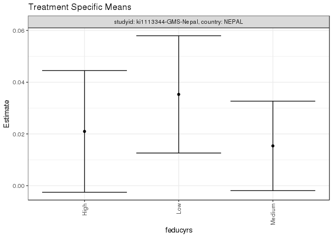

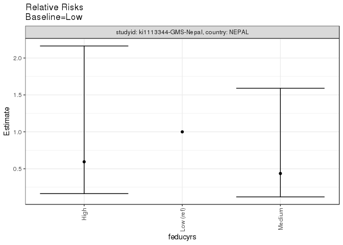

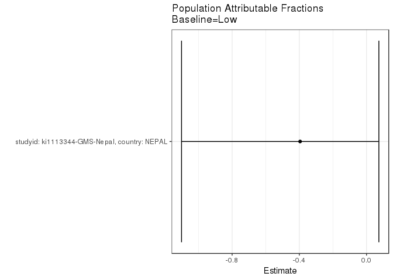

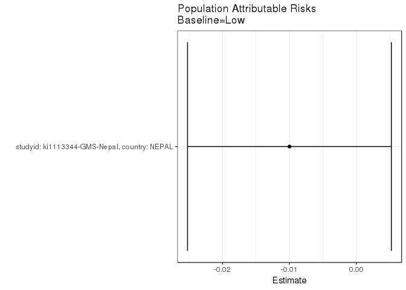

## Results Table

### Parameter: TSM

| studyid | country | intervention_level | baseline_level | estimate | ci_lower | ci_upper |
| --- | --- | --- | --- | --- | --- | --- |
| ki1113344-GMS-Nepal | NEPAL | Low | NA | 0.0352941 | 0.0126272 | 0.0579611 |
| ki1113344-GMS-Nepal | NEPAL | Medium | NA | 0.0153846 | -0.0019045 | 0.0326738 |
| ki1113344-GMS-Nepal | NEPAL | High | NA | 0.0209790 | -0.0025300 | 0.0444881 |

### Parameter: E(Y)

| studyid | country | intervention_level | baseline_level | estimate | ci_lower | ci_upper |
| --- | --- | --- | --- | --- | --- | --- |
| ki1113344-GMS-Nepal | NEPAL | NA | NA | 0.0252951 | 0.0126465 | 0.0379437 |

### Parameter: RR

| studyid | country | intervention_level | baseline_level | estimate | ci_lower | ci_upper |
| --- | --- | --- | --- | --- | --- | --- |
| ki1113344-GMS-Nepal | NEPAL | Low | Low | 1.0000000 | 1.0000000 | 1.000000 |
| ki1113344-GMS-Nepal | NEPAL | Medium | Low | 0.4358974 | 0.1194674 | 1.590447 |
| ki1113344-GMS-Nepal | NEPAL | High | Low | 0.5944056 | 0.1633628 | 2.162781 |

### Parameter: PAR

| studyid | country | intervention_level | baseline_level | estimate | ci_lower | ci_upper |
| --- | --- | --- | --- | --- | --- | --- |
| ki1113344-GMS-Nepal | NEPAL | Low | NA | -0.009999 | -0.0252273 | 0.0052293 |

### Parameter: PAF

| studyid | country | intervention_level | baseline_level | estimate | ci_lower | ci_upper |
| --- | --- | --- | --- | --- | --- | --- |
| ki1113344-GMS-Nepal | NEPAL | Low | NA | -0.3952941 | -1.10104 | 0.0733897 |